# Inferência sobre avaliação de filmes

9 de setembro de 2016

# PERGUNTA 1:

Foi escolhida a trilogia de “O poderoso chefão” para realizar a análise.

Godfather, The (1972) - Temos uma amostra de 210 avaliações. Godfather: Part II, The (1974) - Temos uma amostra de 140 avaliações. Godfather: Part III, The (1990) - Temos uma amostra de 54 avaliações.

Nosso objetivo inicial é analisar a média das avaliações dessas amostras e assim inferir qual dos episódios foi o melhor avaliado pela audiência. Depois, analisaremos a variância dessas notas a fim de observar em qual filme houve uma maior variação nas avaliações.

Inicialmente, vamos observar uma resumo das avaliações de cada filme. Levando em conta apenas os dados amostrais, os dois primeiros filmes são os melhores avaliados em termos de média/mediana, enquanto o terceiro está bem abaixo.

Podemos observar isso também a partir de um histograma. Os dois primeiros filmes possuem bem mais notas máximas que o terceiro.

```
##    Min. 1st Qu.  Median    Mean 3rd Qu.    Max.
##   1.000   4.000   5.000   4.393   5.000   5.000
```

```
##    Min. 1st Qu.  Median    Mean 3rd Qu.    Max.
##   1.000   4.000   4.500   4.261   5.000   5.000
```

```
##    Min. 1st Qu.  Median    Mean 3rd Qu.    Max.
##   1.000   2.625   3.000   3.259   4.000   5.000
```

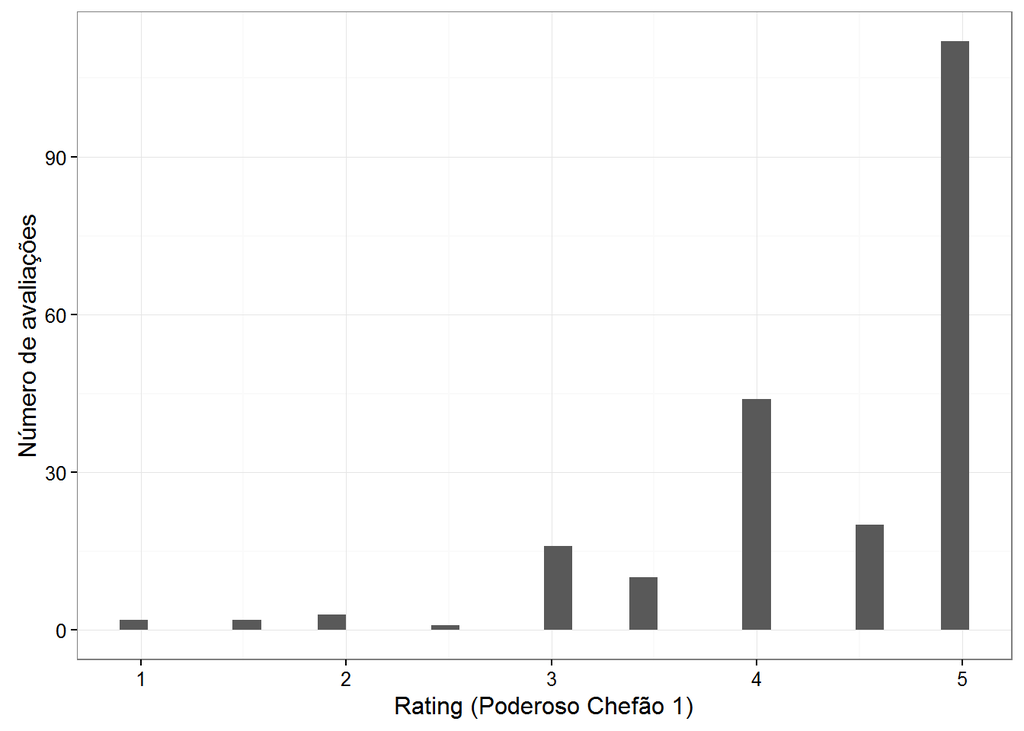

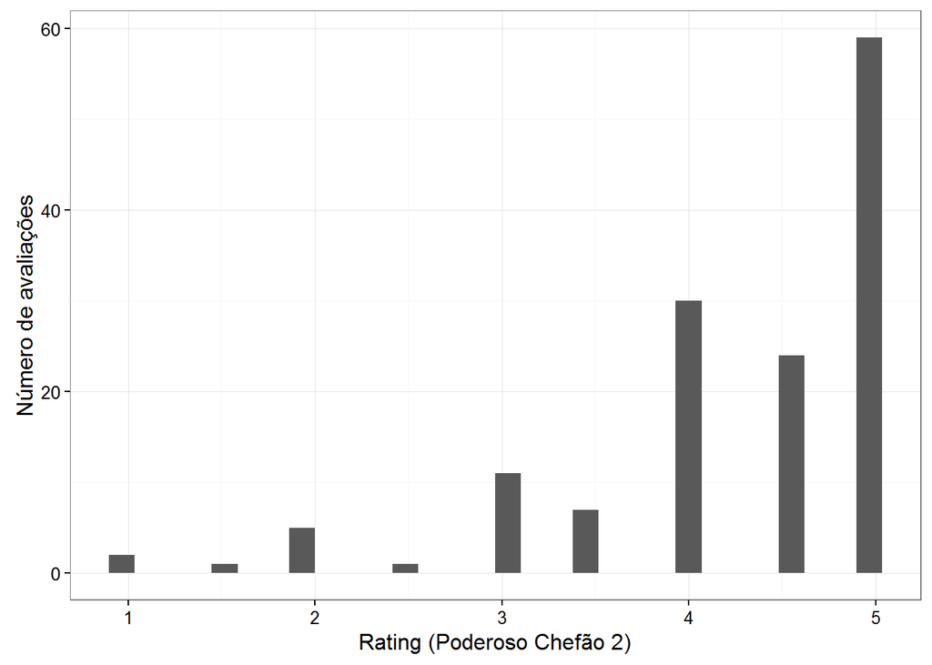

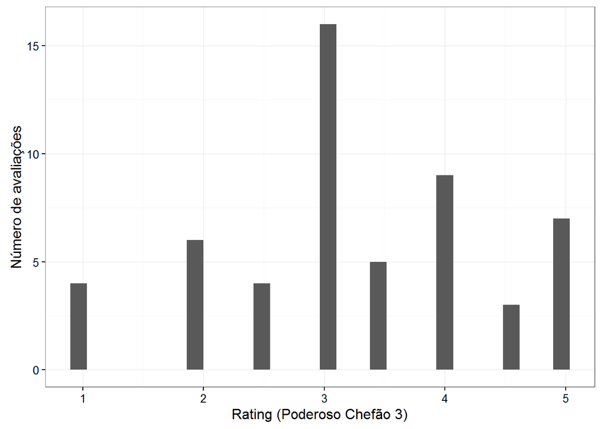

A partir das médias das amostras citadas anteriormente, podemos tentar inferir algo sobre a verdadeira média das avaliações de cada filme, ou seja, a opinião da audiência sobre os mesmos. Utilizando um nível de confiança de 95%, vamos encontrar um intervalo de confiança para a média real das avaliações de cada filme.

Se colhermos n amostras de mesmo tamanho e calcularmos o intervalo de confiança para cada uma delas, espera-se que em 95% dos casos esse intervalo calculado contenha a verdadeira média.

Abaixo temos o resultado e um gráfico para melhor analisá-los. Os dois primeiros filmes receberam as melhores avaliações. Os intervalos para os dois se interceptam, mas mesmo assim podemos notar uma certa superioridade do filme 1 (com rating médio entre 4.26 e 4.49), que possui um intervalo menor (erro menor) por termos uma amostra maior de avaliações.

```
## [1] "Intervalo de confiança para média - O Poderoso Chefão 1"
```

```
##                  2.5%    97.5%
## mean(rating) 4.261905 4.492857
```

```
## [1] "Intervalo de confiança para média - O Poderoso Chefão 2"
```

```
##                  2.5%    97.5%
## mean(rating) 4.092857 4.392857
```

```
## [1] "Intervalo de confiança para média - O Poderoso Chefão 3"
```

```
##                  2.5%    97.5%
## mean(rating) 2.953704 3.546296
```

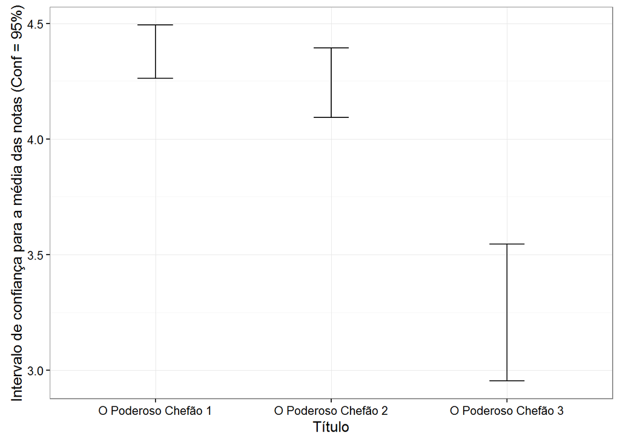

Vamos usar o mesmo princípio para observar a variância das avaliações com o objetivo de verificar em qual filme houve uma maior variação nas notas.

Os três intervalos de confiança se interceptam em algum ponto, impedindo conclusões totalmente precisas. Apesar disso, pela imagem podemos ver que o filme 3 foi aquele que sofreu uma maior variação nas avaliações atribuídas. Os filmes 1 e 2 apresentaram resultados próximos assim como na média, com uma interseção considerável entre seus intervalos.

```
## [1] "Intervalo de confiança para  - O Poderoso Chefão 1"
```

```
##                  2.5%     97.5%
## var(rating) 0.5404567 0.9816261
```

```
## [1] "Intervalo de confiança - O Poderoso Chefão 2"
```

```
##                  2.5%    97.5%
## var(rating) 0.6003469 1.179256
```

```
## [1] "Intervalo de confiança - O Poderoso Chefão 3"
```

```
##                  2.5%    97.5%
## var(rating) 0.8740723 1.752009
```

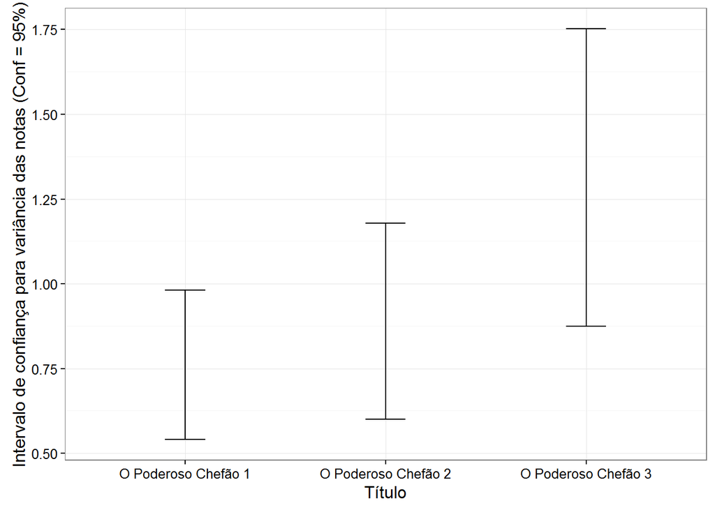

# PERGUNTA 2

Considerando todas as avaliações sobre todos os filmes, vamos verificar se há alguma relação entre as notas recebidas e a quantidade de gêneros presentes no filme. Dado que temos dados amostrais, vamos construir um intervalo de confiança para médias das avaliações de filmes que contém entre 1 e 6 gêneros.

Com 95% de confiança, tem-se por exemplo, que a média de avaliações das pessoas para filmes com 5 gêneros está entre 3.54 e 3.60, aproximadamente. A explicação é a mesma para as demais quantidades gêneros.

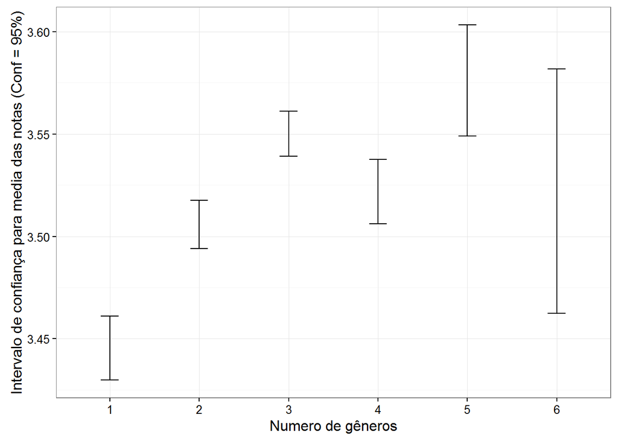

Agora vamos calcular a diferença entre as médias de todas as avaliações sobre filmes com apenas 1 gênero e 5 gêneros. Pelo gráfico anterior, já percebemos claramente que os usuários dão uma nota maior a filmes com 5 gêneros, mas a diferença é muito pequena.

Essa diferença citada está entre 0.1 e 0.16, aproxidamente, com 95% de confiança. Ou seja, é uma diferença significativa, mas que na prática não serve praticamente de nada. Podemos concluir assim, que a quantidade de gêneros presentes em um filme não interfere na nota que as pessoas atribuem ao mesmo.

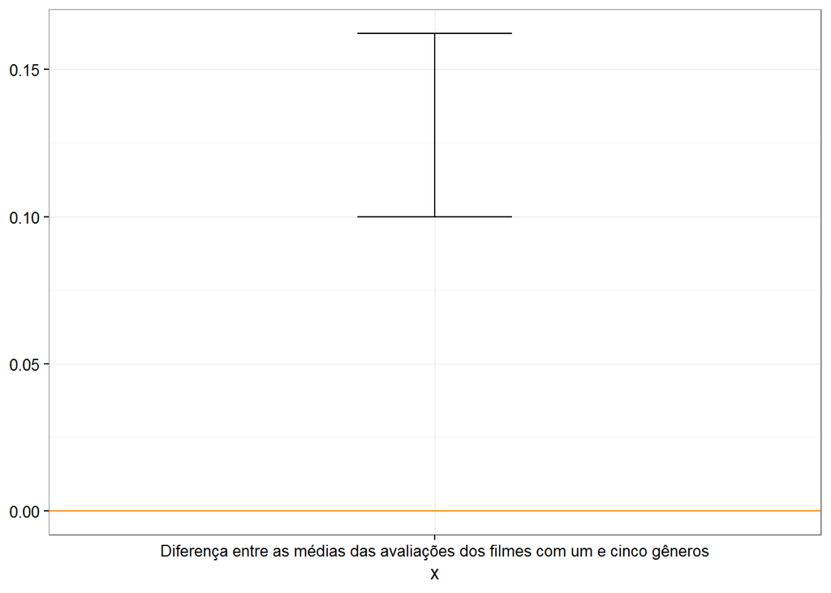